# Chess Elo Prediction — v3

**Multi-task neural network: BiLSTM with attention + static features + optional sequence autoencoder.**

## 0 — Imports

## 1 — Config

Everything in one place. Read the comments — they explain what to change for laptop vs GPU runs.

```
Device : cpu  |  AMP : False  |  CPU threads : 14
Sequential=False  AE=True  DistTarget=True
```

## 2 — Data Loading

```
Loaded 2,000,000 games in 94.7s
Removed 677,622 games by termination
Kept 1,064,637 games after TC filter (removed 251,972)
Elo — White 712–2921,  Black 752–2920
```

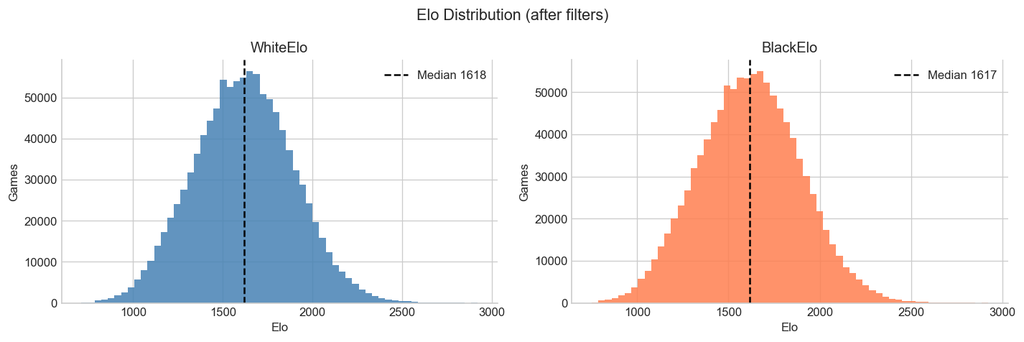

## 3 — Feature Extraction *(cached)*

Board and clock features are saved to `cache/` so they only recompute when you change the data.

```
Extracting board features...
  Done in 861.0s — 35 cols
Extracting clock features...
  Done in 61.6s — 10 cols
Full feature matrix: (1064637, 69)
```

## 4 — Move Tokenisation

```
Dropped 14,056 short games
Vocab size : 11,447   Games ready: 1,050,581
```

## 5 — Soft Distribution Targets *(Ouzounis-style)*

Rather than regressing to a single number, the model learns to output a probability distribution over 40 Elo buckets (each 100 points wide). The ground truth for each player is a Gaussian centred on their actual Elo with σ=200, then discretised into those buckets. This captures the fact that a player's single-game performance is noisy around their true rating.

```
Distribution for 1600: peak bin=1550,  recovered Elo=1600
```

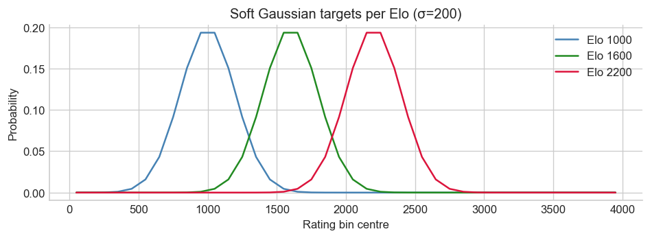

## 6 — Feature Selection, Split & Scaling

```
Static columns: 45
  [on] game_structure      (3 cols)
  [on] checks              (4 cols)
  [on] captures            (5 cols)
  [on] castling            (2 cols)
  [on] style               (9 cols)
  [on] engine_quality      (10 cols)
  [on] clock               (10 cols)
  [on] tc_meta             (2 cols)
Split — train:840,464  val:105,058  test:105,059
Scaling done (fit on train only)
```

## 7 — Sequence Autoencoder *(optional but recommended on CPU)*

The LSTM adds signal but is slow on CPU: a 200k-game run with `USE_SEQUENTIAL=True` takes hours. The autoencoder is the fix. We train it **once**, then use its **encoder half** to compress each game's move sequence into a `AE_LATENT_DIM`-dimensional vector and cache those vectors. The main model then just reads those cached vectors as extra static features — no recurrence at all during the main training loop.

**Install requirement:** `pip install torch` (already required). No extra package needed — the AE is a vanilla LSTM autoencoder built with PyTorch.

Set `USE_AE = True` in the Config cell to use this cell

```
Training sequence autoencoder...
  AE epoch 1/2  loss=6.0733
  AE epoch 2/2  loss=5.1137
AE embeddings saved: (1050581, 32)
AE embeddings ready — 32 dims per game
```

## 8 — Dataset & DataLoaders

```
Building datasets...
  Built in 2363.2s   total_static_dim=77
Batches/epoch: 6,567
```

## 9 — Model

Output head: when `USE_DIST_TARGET=True` the model predicts a 40-bin softmax distribution over rating ranges. Point estimate = weighted mean of that distribution. When False, direct Huber regression.

```
Trainable parameters: 1,434,353
```

## 10 — Training

```
Epoch  1/10  train 1.2137  val 1.1217  MAE W:218 B:217  lr 2.93e-04  297.4s
Epoch  2/10  train 1.0343  val 1.0241  MAE W:204 B:203  lr 2.73e-04  87.8s
Epoch  3/10  train 1.0001  val 1.0478  MAE W:207 B:207  lr 2.41e-04  84.3s
Epoch  4/10  train 0.9786  val 1.0292  MAE W:206 B:204  lr 2.02e-04  74.0s
Epoch  5/10  train 0.9622  val 1.0515  MAE W:208 B:209  lr 1.57e-04  84.5s
Early stopping at epoch 5
```

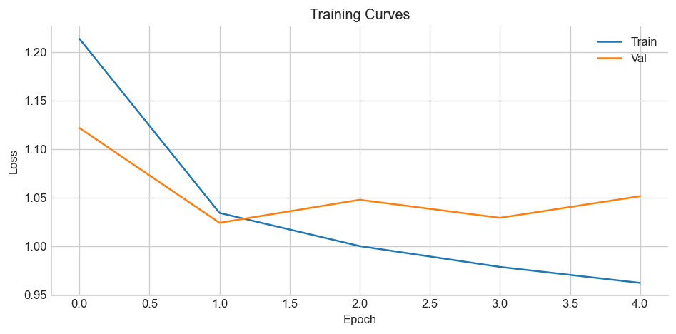

## 11 — Evaluation

```
Loaded: chess_elo_v3_2e+06.pth
MAE    — White: 202.8  Black: 202.9  Combined: 202.8
Median — White: 166.9  Black: 167.2
Within 100 Elo: 31.7%
Within 200 Elo: 57.8%
Within 300 Elo: 76.6%
```

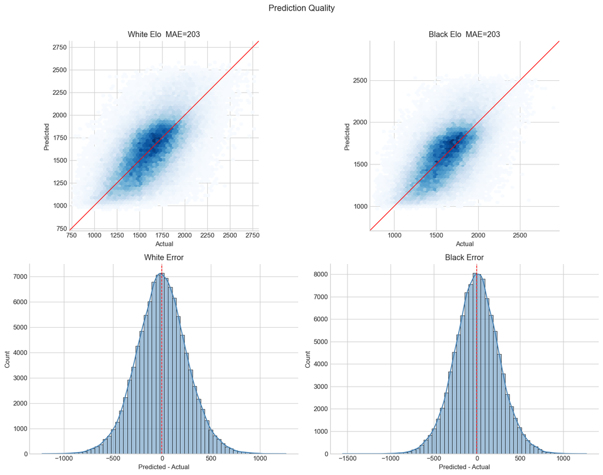

```
MAE by bracket:
----------------------------------------
           (0, 1000]  MAE=  269  n=1,765
        (1000, 1200]  MAE=  186  n=11,843
        (1200, 1400]  MAE=  191  n=32,099
        (1400, 1600]  MAE=  195  n=53,918
        (1600, 1800]  MAE=  194  n=56,671
        (1800, 2000]  MAE=  213  n=36,358
        (2000, 2200]  MAE=  252  n=13,676
        (2200, 2500]  MAE=  276  n=3,583
        (2500, 4000]  MAE=  332  n=205
```

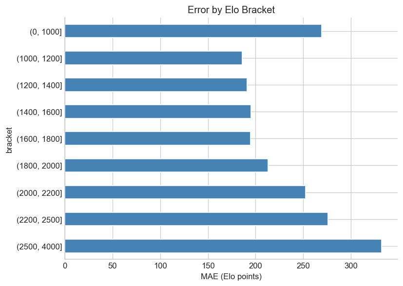

## 12 — Distribution Output Visualisation *(Ouzounis-inspired)*

```
Distribution animation requires USE_DIST_TARGET=True and USE_SEQUENTIAL=True.
With the current config we just show the final distribution for a sample game.
```

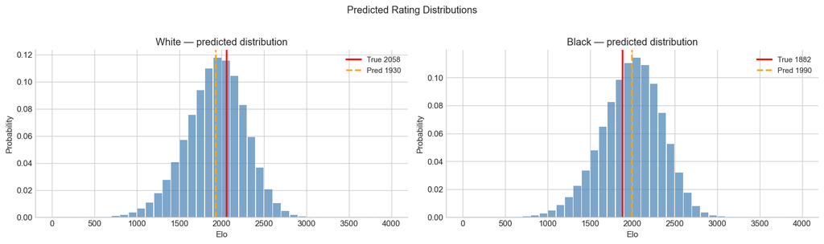

## 13 — Attention Heatmap

```
Attention heatmap requires USE_SEQUENTIAL=True.
```

## 14 — Latent Space Clustering

```
Running t-SNE on 3000 vectors...
```

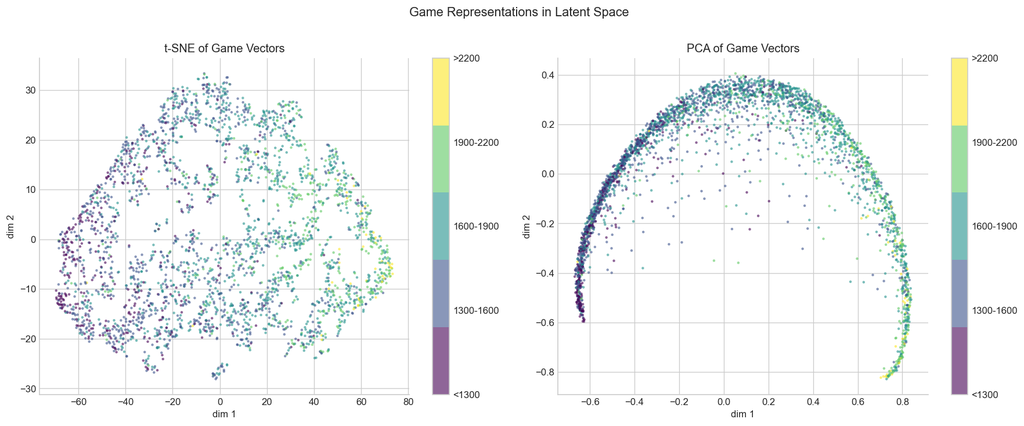

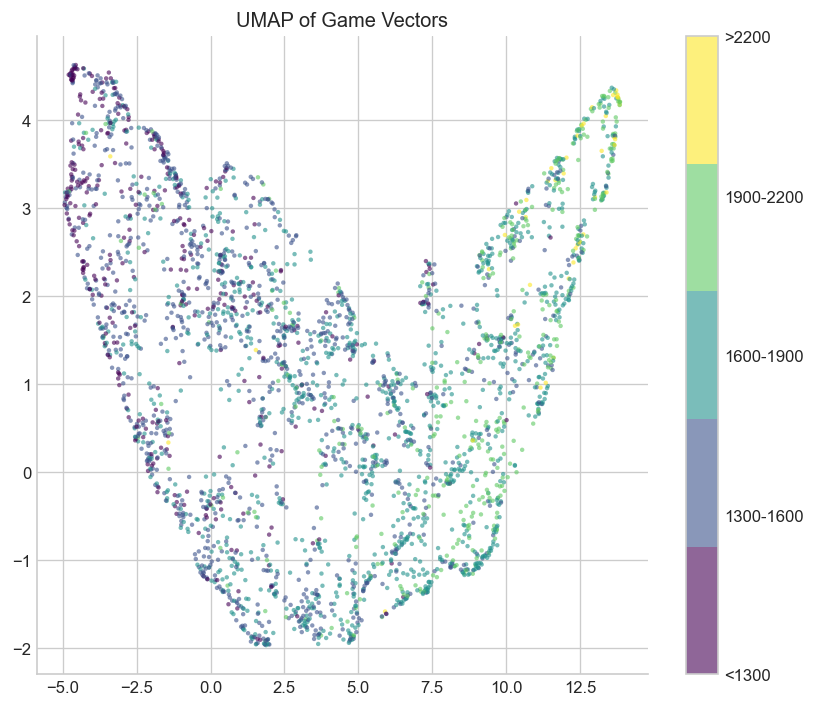

## 15 — Feature Importance & Ablation

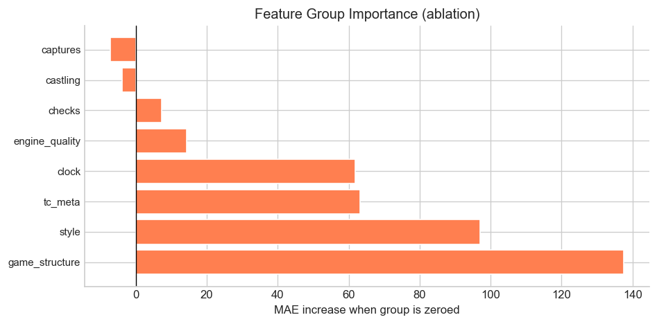

```
  game_structure      Δ=+137.5
  style               Δ=+97.1
  tc_meta             Δ=+63.3
  clock               Δ=+61.8
  engine_quality      Δ=+14.3
  checks              Δ=+7.4
  castling            Δ=-3.8
  captures            Δ=-7.2
```

## 16 — Progressive Elo Estimation

```
Progressive estimation requires USE_SEQUENTIAL=True.
```

## 17 — Opening Analysis (ECO codes)

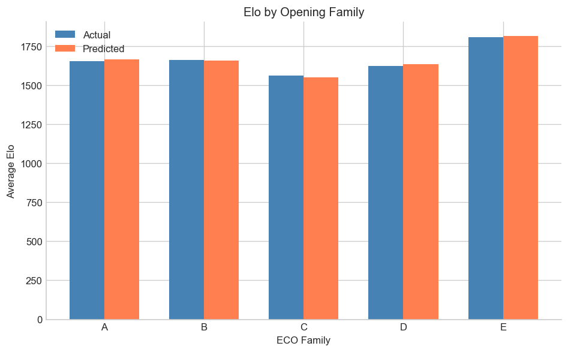

```
Top 5 highest-Elo ECO codes (min 10 games):
    A14  avg Elo: 2081  (n=12)
    B96  avg Elo: 2077  (n=12)
    D86  avg Elo: 2070  (n=10)
    E97  avg Elo: 2048  (n=23)
    E06  avg Elo: 2022  (n=22)

Bottom 5 lowest-Elo ECO codes (min 10 games):
    C20  avg Elo: 1417  (n=3558)
    C49  avg Elo: 1450  (n=44)
    C40  avg Elo: 1461  (n=2014)
    C22  avg Elo: 1463  (n=538)
    C46  avg Elo: 1495  (n=1259)
```

## 18 — Anomaly Detection

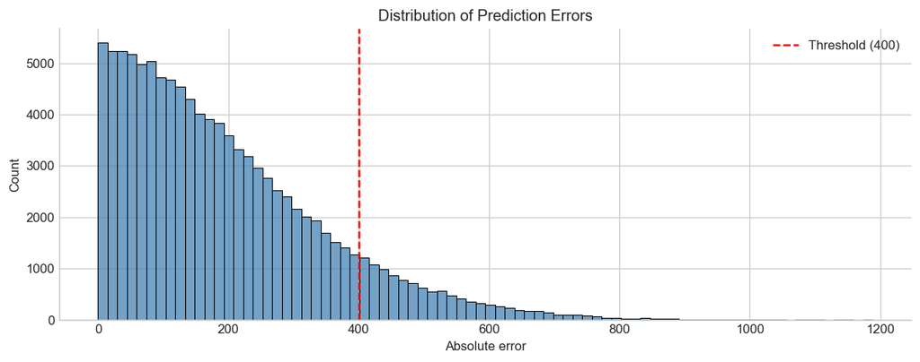

```
Flagged 11252 games > 400 Elo  (10.7%)

Top 15 OVERPERFORMERS
   Predicted      Actual      Diff
  --------------------------------
        2469        1280     +1189
        2429        1288     +1142
        2385        1275     +1110
        2379        1270     +1109
        2336        1266     +1070
        2270        1216     +1054
        2385        1352     +1033
        2445        1416     +1029
        2384        1360     +1024
        2351        1332     +1019
```

[output cut: 24 more lines]

## 19 — Single-Game Inference *(paste any PGN)*

Paste a PGN string into `EXAMPLE_PGN` and run the cell. The model will output predicted White and Black Elos along with the full probability distribution. Works without clocks — clock features just fill with NaN.

Copy a PGN from Lichess or chess.com (the 'Share' button), paste it below.

```
=============================================
  White Elo   predicted:  1743   actual: 1546
  Black Elo   predicted:  1718   actual: 1534
=============================================
```

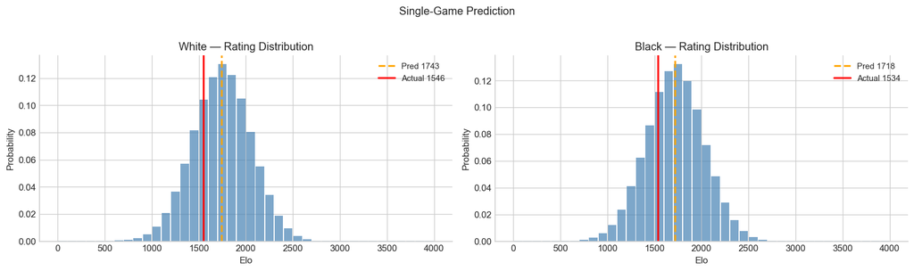

## 20 — Export